# Tugas_APG_8

## 8.14

```r
sweet_rate <- c(3.7, 5.7, 3.8, 3.2, 3.1, 4.6, 2.4, 7.2, 6.7, 5.4, 3.9, 4.5, 3.5, 4.5, 1.5, 8.5, 4.5, 6.5, 4.1, 5.5)
sodium <- c(48.5, 65.1, 47.2, 53.2, 55.5, 36.1, 24.8, 33.1, 47.4, 54.1, 36.9, 58.8, 27.8, 40.2, 13.5, 56.4, 71.6, 52.8, 44.1, 40.9)
potassium <- c(9.3, 8, 10.9, 12, 9.7, 7.9, 14, 7.6, 8.5, 11.3, 12.7, 12.3, 9.8, 8.4, 10.1, 7.1, 8.2, 10.9, 11.2, 9.4)

sweet_data <- cbind(sweet_rate, sodium, potassium)
```

```r
S_sweet <- cov(sweet_data)
S_sweet
```

```
##            sweet_rate   sodium potassium
## sweet_rate   2.879368  10.0100 -1.809053
## sodium      10.010000 199.7884 -5.640000
## potassium   -1.809053  -5.6400  3.627658
```

```r
sweet_eig <- eigen(S_sweet)
sweet_eig_val <- sweet_eig$values
sweet_eig_vec <- sweet_eig$vector
```

```r
sweet_eig_val
```

```
## [1] 200.462464   4.531591   1.301392
```

```r
sweet_eig_vec
```

```
##             [,1]        [,2]        [,3]
## [1,] -0.05084144 -0.57370364  0.81748351
## [2,] -0.99828352  0.05302042 -0.02487655
## [3,]  0.02907156  0.81734508  0.57541452
```

```r
prop_var_sweet <- c()
temp <- 0

for(i in c(1:3)){
  temp <- temp + sweet_eig_val[i]
  prop_var <- (temp / sum(sweet_eig_val)) * 100
  prop_var_sweet <- append(prop_var_sweet, prop_var)
}

prop_var_sweet
```

```
## [1]  97.17251  99.36916 100.00000
```

```r
rho_sweet <- matrix(nrow = 3,  ncol = 3)
for(i in c(1:3)){
  for(j in c(1:3))
    rho_sweet[j, i] <- (sweet_eig_vec[j, i] * sqrt(sweet_eig_val[i])) / sqrt(S_sweet[j, j])
}

rho_sweet
```

```
##            [,1]         [,2]         [,3]
## [1,] -0.4242148 -0.719721231  0.549584543
## [2,] -0.9999661  0.007985155 -0.002007747
## [3,]  0.2161084  0.913519072  0.344644843
```

```r
componets_sweet <- matrix(nrow = 20, ncol = 3)
for(i in c(1:3)){
  for(j in c(1:20)){
    componets_sweet[j, i] <- t(sweet_eig_vec[, i]) %*% sweet_data[j, ]
  }
}
```

```r
pca_sweet_data <- prcomp(sweet_data, scale = F)
```

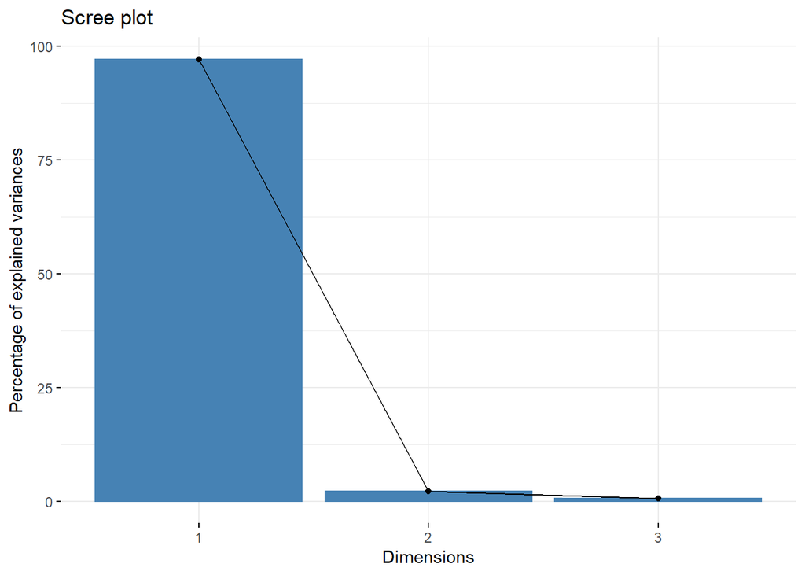

```r
fviz_eig(pca_sweet_data)
```

Jika kita melihat dari hasil scree plot dan proporsi varians nya, dapat kita simpulkan bahwa komponen prinsipal yang dipakai untuk menggantikan variabel x adalah komponen prinsipal pertama.

Q-Q Plot dari PC1

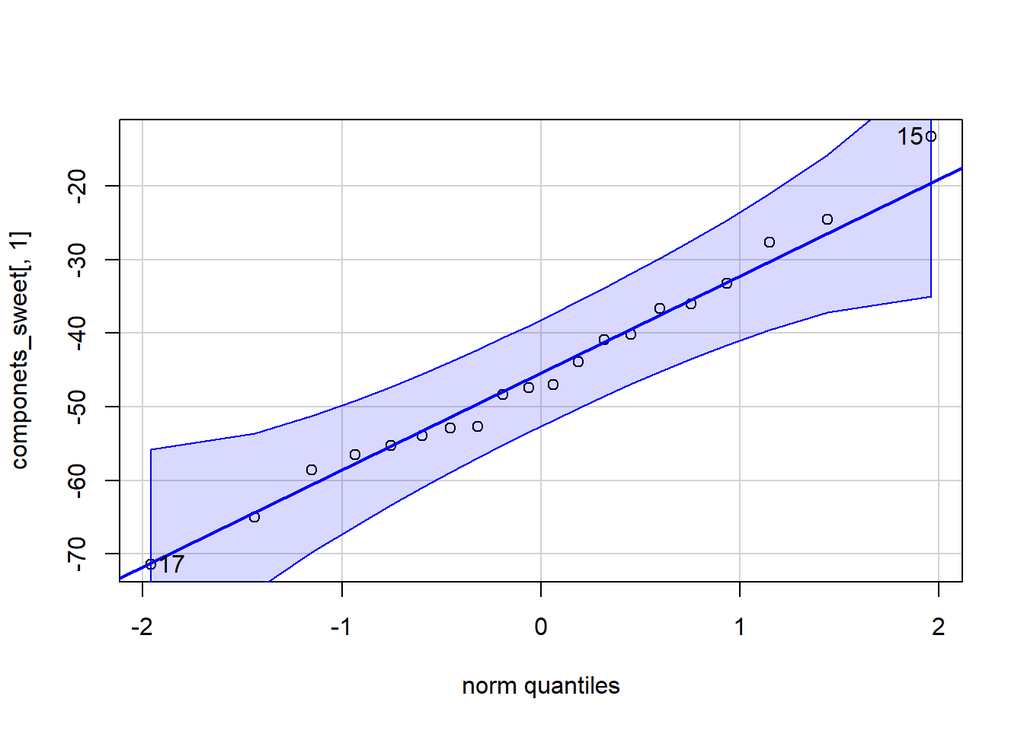

```
## [1] 15 17
```

```r
car::qqPlot(componets_sweet[, 1])
```

```r
shapiro.test(componets_sweet[, 1])
```

```
##
##  Shapiro-Wilk normality test
##
## data:  componets_sweet[, 1]
## W = 0.98562, p-value = 0.9851
```

Dari hasil q-q plot dan uji normalitas di atas, terlihat bahwa komponen prinsipal pertama yang digunakan sebagai pengganti variabel x pada data sebelumnya memiliki nilai p-value > $\alpha$, sehingga PC1 berdistribusi normal.